# All Results

Jude Bayham

March 16, 2020

# Setup

Install these packages if neccessary.

The objective of this supplement is to provide detail on the analysis of CCE characteristics in the historical and present-day time periods. We begin by detailing the methods used to compare the CCEs across time followed by an investigation of the climate, mineral access, and proximity to federal lands.

# Methods

Our primary method to compare the historical and present-day CCEs is a linear regression of the characteristic as a function of a binary indicator for present-day lands (and an intercept), which amounts to simple ANOVA test of whether the means are equal in the historical and present-day CCEs. All statistical tests are conducted using cluster-robust standard errors which account for heteroskedasticity and serial correlation that may exist within a tribe due to the proximity of CCEs within a tribe’s range.

We assess the robustness of our estimate using alternative model specifications based on the statistical properties of the variable being analyzed. We estimate a weighted regression model that effectively places equal weight on each tribe given the number of CCEs varies with the historical range of the tribe. Larger, more dominant, or tribes with CCEs in the Eastern US tend to include more CCEs, which effectively increases the weight on those tribes in a simple regression setting. We also estimate the models with tribe fixed-effects and random-effects to account for potential trends common across historical and present-day lands within a tribe.

# CCEs Inhabited

We compare the spatial extent of tribe’s historical and present-day areas as measured by the number of CCEs. We estimate the difference between the number of CCEs reported as historical lands and the number of CCEs reported as present-day lands using several regression models to assess the robustness of the relationship. Column 1 shows the results of an ordinary least squares regression based on the subset of tribes that inhabited more than one CCE in both the historical and present. Column 2 estimates a similar model using the same data, but observations are inversely weighted to the number of CCEs inhabited by each tribe. Since tribes vary in their size and spatial extent, a standard OLS model places more weight on the impact to larger tribes because they represent more observations in the dataset. Therefore, Model 2 reweights the data to place equal weight on each tribe rather than the population as a whole. Columns 3 and 4 replicate specifications in columns 1 and 2, respectively, except they include all observations including tribes that have only observations in either the historical or present-day periods. Column 5 estimates a similar specification using a Poisson regression model.

**Table S1: Extent of Area Occupied**

|  | Dependent Variable: Number of CCEs |  |  |  |  |
| --- | --- | --- | --- | --- | --- |
|  | OLS | Weighted OLS | OLS | Weighted OLS | Poisson |
|  | (1) | (2) | (3) | (4) | (5) |
| Historical (Intercept) | 146.700*** | 40.875*** | 125.591*** | 24.161*** | 4.988*** |
|  | (115.383, 178.017) | (31.345, 50.405) | (98.040, 153.142) | (19.282, 29.039) | (4.775, 5.202) |
| Present-day Change | -136.303*** | -37.375*** | -117.750*** | -22.407*** | -2.647*** |
|  | (-164.311, -108.294) | (-46.521, -28.229) | (-142.694, -92.806) | (-27.081, -17.733) | (-2.961, -2.332) |
| Obs | 8,165 | 8,165 | 10,528 | 10,528 | 8,165 |
| *Note:* | p<0.1; p<0.05; p<0.01 |  |  |  |  |
|  | 95% confidence intervals in parentheses. |  |  |  |  |
|  | All inference is based on tribe-clustered standard errors, which are robust to serial correlation and heteroskedasticity. |  |  |  |  |

The results indicate that tribes occupied far fewer CCEs in the present period relative to the historical period. The results in column 1 suggest that tribes occupied an average of 146.7 CCEs during the historical period. By the present day, the average number of CCEs fell by 136.303 (a 92.9% reduction). The relationship is robust to all specifications. However, the results of column 2 (weighted OLS) indicate that the abolute estimated effect is heavily influenced by large tribes, yet the percentage reduction in CCEs is of similar magnitude (91.4%).

# Changes in Historical and Present-Day CCE Characteristics

## Climate Variables

We analyze the difference between climate variables in the pre-migration lands to the post-migration lands. We focus on heat index, drought, annual precipitation, and wildfire hazard potential.

### Heat

We begin with the heat index, which represents the number of days per year that a CCE exceeded 100 degrees F.

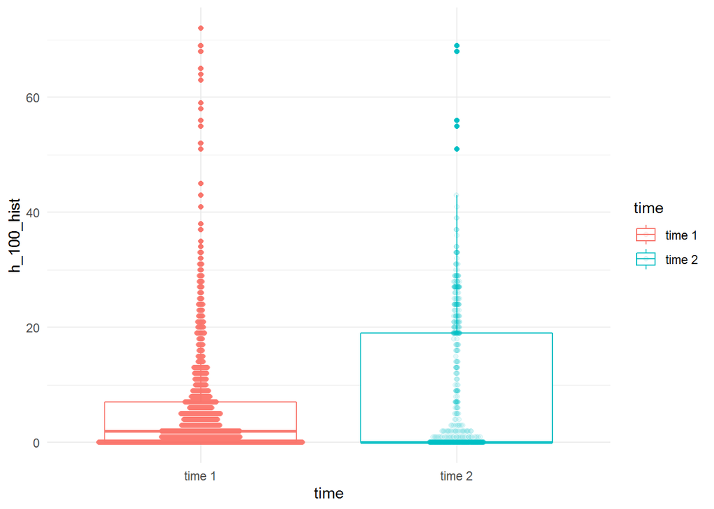

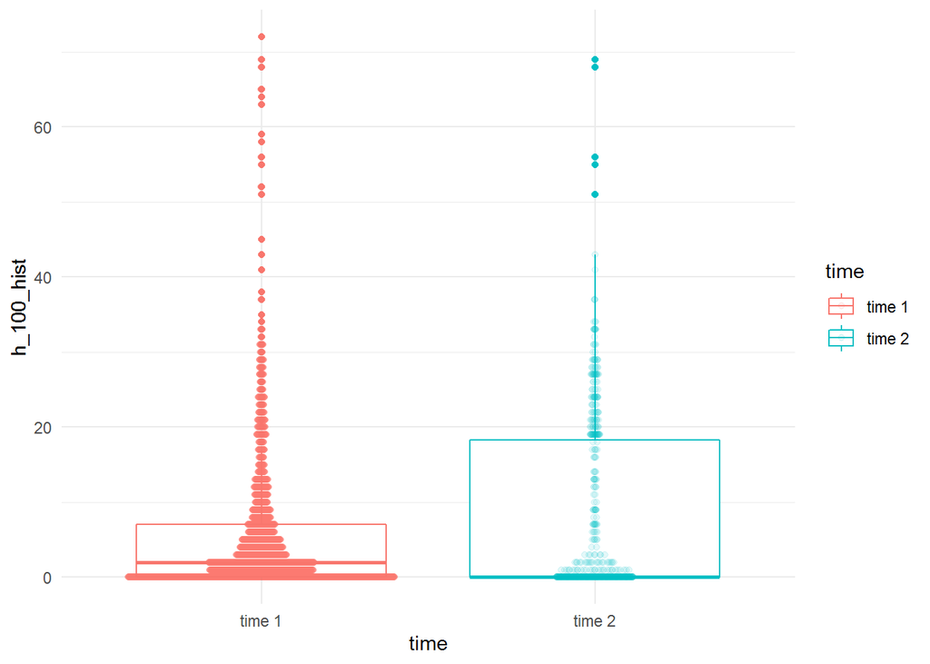

**Table S2: Extreme Heat**

|  | Dependent Variable: Days/Year in excess of 100 degrees F |  |  |  |  |
| --- | --- | --- | --- | --- | --- |
|  | OLS | Weighted OLS | OLS | Weighted OLS | Poisson |
|  | (1) | (2) | (3) | (4) | (5) |
| Historical (Intercept) | 5.503*** | 4.751*** | 5.613*** | 4.717*** | 1.705*** |
|  | (4.100, 6.906) | (3.302, 6.199) | (4.463, 6.763) | (3.850, 5.585) | (1.450, 1.960) |
| Present-day Change | 2.604*** | 2.543*** | 2.917*** | 2.879*** | 0.387*** |
|  | (0.734, 4.474) | (1.601, 3.485) | (1.004, 4.830) | (1.557, 4.202) | (0.149, 0.625) |
| Obs | 8,165 | 8,165 | 10,528 | 10,528 | 8,165 |
| *Note:* | p<0.1; p<0.05; p<0.01 |  |  |  |  |
|  | 95% confidence intervals in parentheses. |  |  |  |  |
|  | All inference is based on tribe-clustered standard errors, which are robust to serial correlation and heteroskedasticity. |  |  |  |  |

The first column of Table S2 presents the results of an OLS regression of heat day CCEs on a dummy variable indicating present-day areas. We estimate the same alternative specifications that were used in Table S1 to assess robustness of the relationship. We find a robust relationship indicating that present-day lands experience more days of extreme heat compared to historical lands.

## Drought

We use the Palmer Drought Severity Index (PDSI) to assess exposure to drought. Specifically, we compare the median PDSI of present-day to historical lands. Note that negative values indicate more drought whereas positive values indicate wetter conditions.

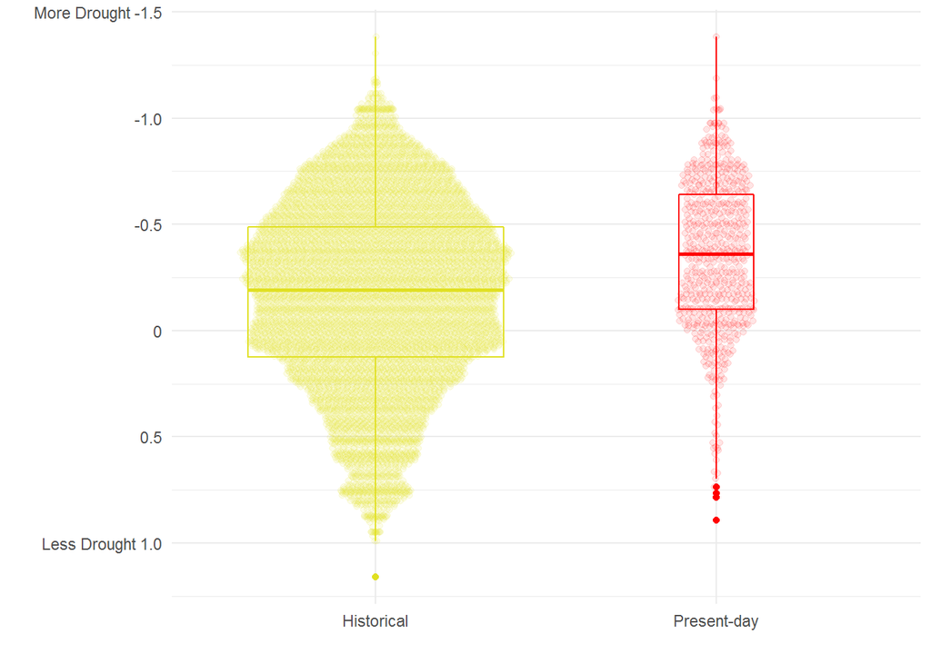

**Table S3: Drought**

|  | Dependent Variable: Median PDSI |  |  |  |  |
| --- | --- | --- | --- | --- | --- |
|  | OLS | Weighted OLS | OLS | Weighted OLS | Tribe FE OLS |
|  | (1) | (2) | (3) | (4) | (5) |
| Historical (Intercept) | -0.164*** | -0.280*** | -0.194*** | -0.423*** |  |
|  | (-0.234, -0.093) | (-0.321, -0.238) | (-0.256, -0.131) | (-0.461, -0.386) |  |
| Present-day Change | -0.181*** | -0.062*** | -0.157*** | 0.077*** | -0.105*** |
|  | (-0.252, -0.111) | (-0.094, -0.030) | (-0.224, -0.090) | (0.030, 0.125) | (-0.159, -0.052) |
| Obs | 8,165 | 8,165 | 10,528 | 10,528 | 8,165 |
| *Note:* | p<0.1; p<0.05; p<0.01 |  |  |  |  |
|  | 95% confidence intervals in parentheses. |  |  |  |  |
|  | All inference is based on tribe-clustered standard errors, which are robust to serial correlation and heteroskedasticity. |  |  |  |  |

The results indicate fairly robust evidence that present-day lands experience more drought than historical CCEs. Columns 1-4 present the results of the unweighted (1 and 3) and weighted OLS (2 and 4) regressions using only tribes represented in the historical and present day (1 and 2) and all observations (3 and 4). The mean PDSI on the historical lands ranges from -0.164 to -0.423. Four of the five models indicate more drought on present-day lands. The weighted OLS regression using all data (column 4) has a positive coefficient on present-day. However, the intercept is considerable lower, which indicates that some tribes that do not appear in both periods have strong influence over the estimate.

## Precipitation

We compare the mean annual precipitation (mm) in present-day and historical CCEs.

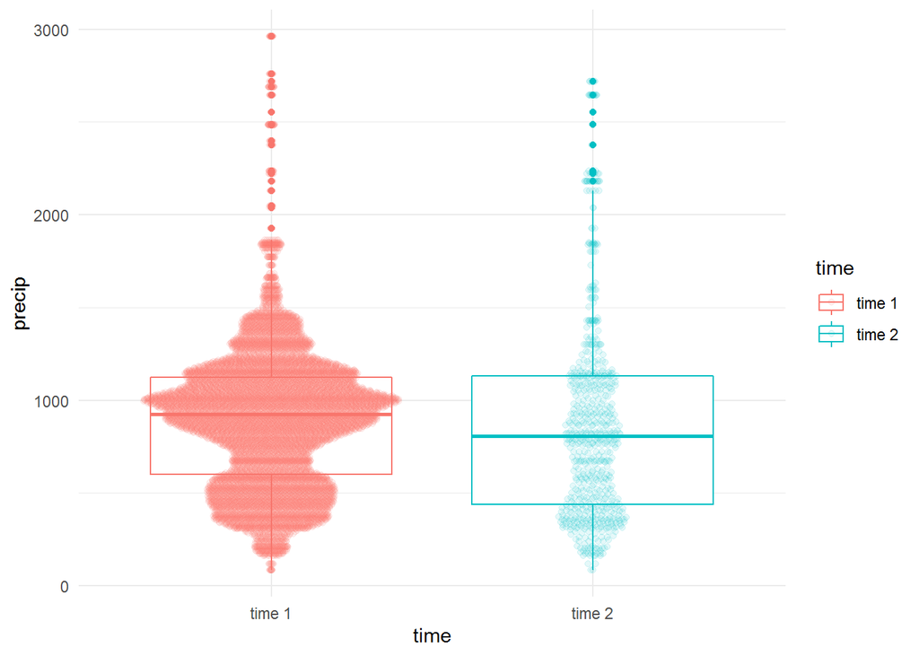

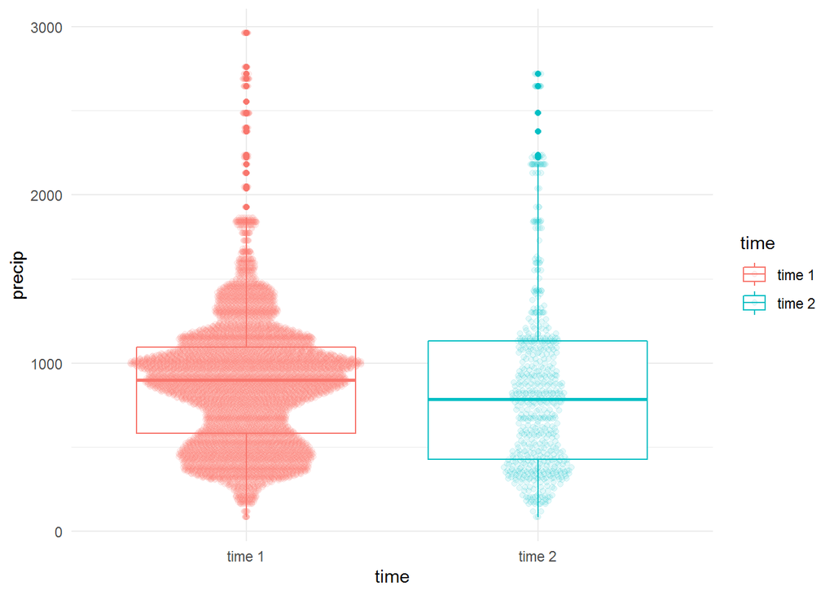

**Table S4: Precipitation**

|  | Dependent Variable: Mean Annual Precipitation (mm) |  |  |  |  |
| --- | --- | --- | --- | --- | --- |
|  | OLS | Weighted OLS | OLS | Weighted OLS | Tribe FE OLS |
|  | (1) | (2) | (3) | (4) | (5) |
| Historical (Intercept) | 899.903*** | 994.945*** | 912.751*** | 934.068*** |  |
|  | (835.365, 964.442) | (907.548, 1,082.342) | (860.356, 965.145) | (883.064, 985.073) |  |
| Present-day Change | -14.019 | 57.623*** | -4.606 | 135.057*** | 6.388 |
|  | (-91.119, 63.081) | (25.416, 89.830) | (-80.285, 71.073) | (73.783, 196.332) | (-35.632, 48.407) |
| Obs | 8,165 | 8,165 | 10,528 | 10,528 | 8,165 |
| *Note:* | p<0.1; p<0.05; p<0.01 |  |  |  |  |
|  | 95% confidence intervals in parentheses. |  |  |  |  |
|  | All inference is based on tribe-clustered standard errors, which are robust to serial correlation and heteroskedasticity. |  |  |  |  |

While the evidence for a difference in precipitation across the present-day and historical CCEs is weak, the weighted OLS regressions indicate that the present-day lands experience slightly more precipitation. This result suggests that there exists a large amount of variation across tribes, and that there are some tribes that occupied more CCEs that experienced less precipitation on some of the lands.

## Wildfire Hazard Potential

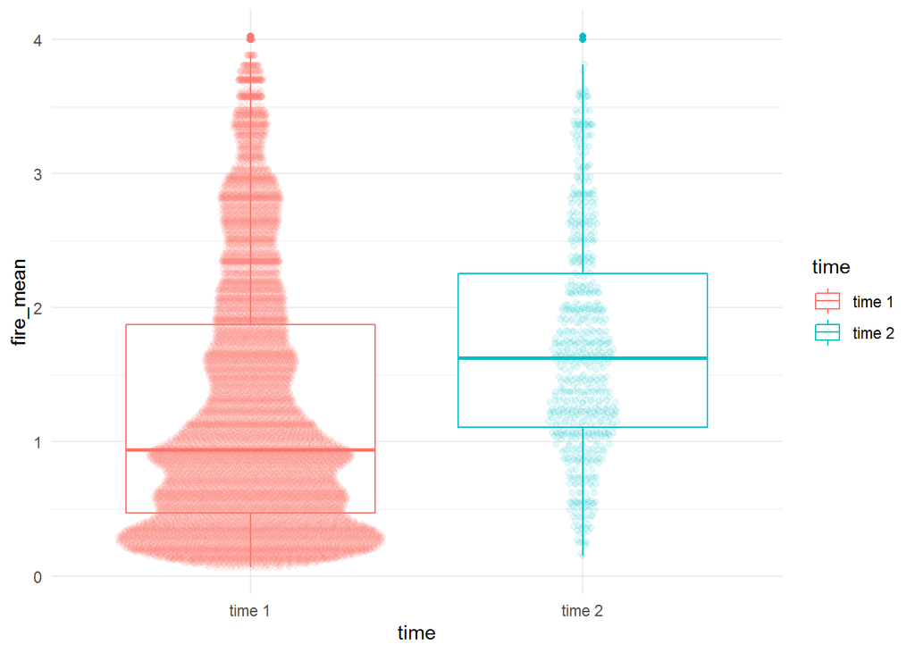

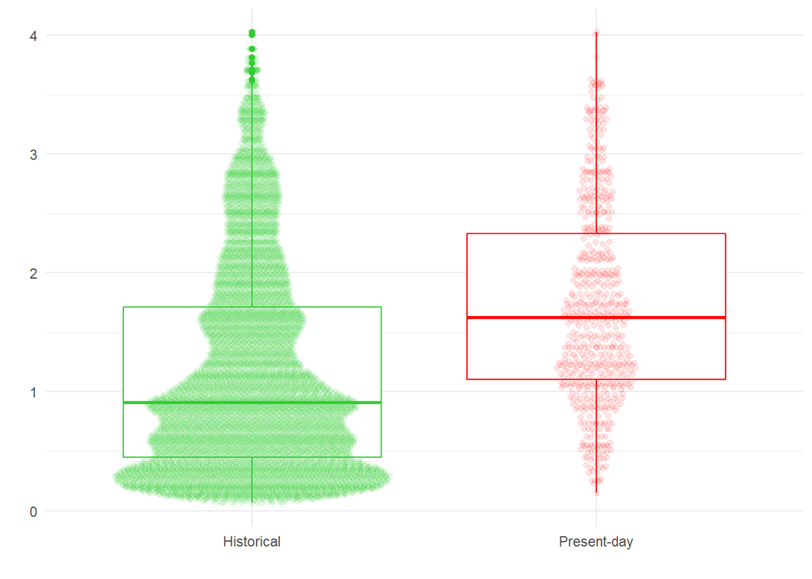

Figure caption: Wildfire hazard potential in historical and present-day CCEs. While indigenous people were concentrated on fewer total CCEs (width of distribution), the mean WHP is higher in the present-day CCEs than the historical.

**Table S5: Wildfire Hazard Potential**

|  | Dependent Variable: Mean Wildfire Hazard Potential |  |  |  |  |
| --- | --- | --- | --- | --- | --- |
|  | OLS | Weighted OLS | OLS | Weighted OLS | Tribe FE OLS |
|  | (1) | (2) | (3) | (4) | (5) |
| Historical (Intercept) | 1.174*** | 1.733*** | 1.250*** | 1.932*** |  |
|  | (1.020, 1.328) | (1.625, 1.841) | (1.110, 1.390) | (1.849, 2.015) |  |
| Present-day Change | 0.550*** | 0.018 | 0.471*** | -0.163*** | 0.138*** |
|  | (0.408, 0.692) | (-0.052, 0.088) | (0.333, 0.610) | (-0.261, -0.066) | (0.043, 0.232) |
| Obs | 8,165 | 8,165 | 10,528 | 10,528 | 8,165 |
| *Note:* | p<0.1; p<0.05; p<0.01 |  |  |  |  |
|  | 95% confidence intervals in parentheses. |  |  |  |  |
|  | All inference is based on tribe-clustered standard errors, which are robust to serial correlation and heteroskedasticity. |  |  |  |  |

We assess the robustness of the comparison with the same battery of alterntive specifications. While the weighted OLS models (columns 2 and 4) cast some doubt on the relationship, the other models suggest that present-day lands have significantly higher wildfire hazard potential.